# Predicting Excercise Pattern

Swarna Kamal Paul

9/18/2017

## Abstract

One thing that people regularly do is quantify how much of a particular activity they do, but they rarely quantify how well they do it. In this project, the goal is to use data from accelerometers on the belt, forearm, arm, and dumbell of 6 participants and predict the manner in which they did the exercise. Data is being collected Using devices such as Jawbone Up, Nike FuelBand, and Fitbit. Using these devices it is now possible to collect a large amount of data about personal activity relatively inexpensively. The predictable variable is created by asking the performers to perform barbell lifts correctly and incorrectly in 5 different ways.

## Getting and processing data

The following section downloads and reads the training and test dataset. Therebay some transformations are applied to make it usable for downstream processes. There are 100 columns which have more than 95% missing values. Those are removed from the dataset. The 1st 5 columns are removed as they are related to user id and timestamp and does not contribute anything in creating the predictor model. Thereafter ran principal component analysis to reduce the dimension even further. The cumulative variance plot shows that first 38 principal components nearly explain 99% variance in the data. Thus the final dataset has only 38 predictors.

```r
set.seed(1000)
download.file("https://d396qusza40orc.cloudfront.net/predmachlearn/pml-training.csv","training.csv")
download.file("https://d396qusza40orc.cloudfront.net/predmachlearn/pml-testing.csv","test.csv")

training <- read.csv("training.csv" , na.strings=c("NA"," ","#DIV/0!") )
test <- read.csv("test.csv")
dim(training)
```

```
## [1] 19622   160
```

```r
#getting missing values
NA_percent_cols<-sapply(1:ncol(training),function (i) {sum(is.na(training[,i]))/19622})
NA_percent_cols<- data.frame(NA_percent=NA_percent_cols,colpos=1:160)
# getting columns with more than 95% missing values
NA_percent_cols <- subset(NA_percent_cols,NA_percent>0.95)
# removing columns with missing values
training <- training[,-NA_percent_cols$colpos]
training<-training[complete.cases(training),]
dim(training)
```

```
## [1] 19622    60
```

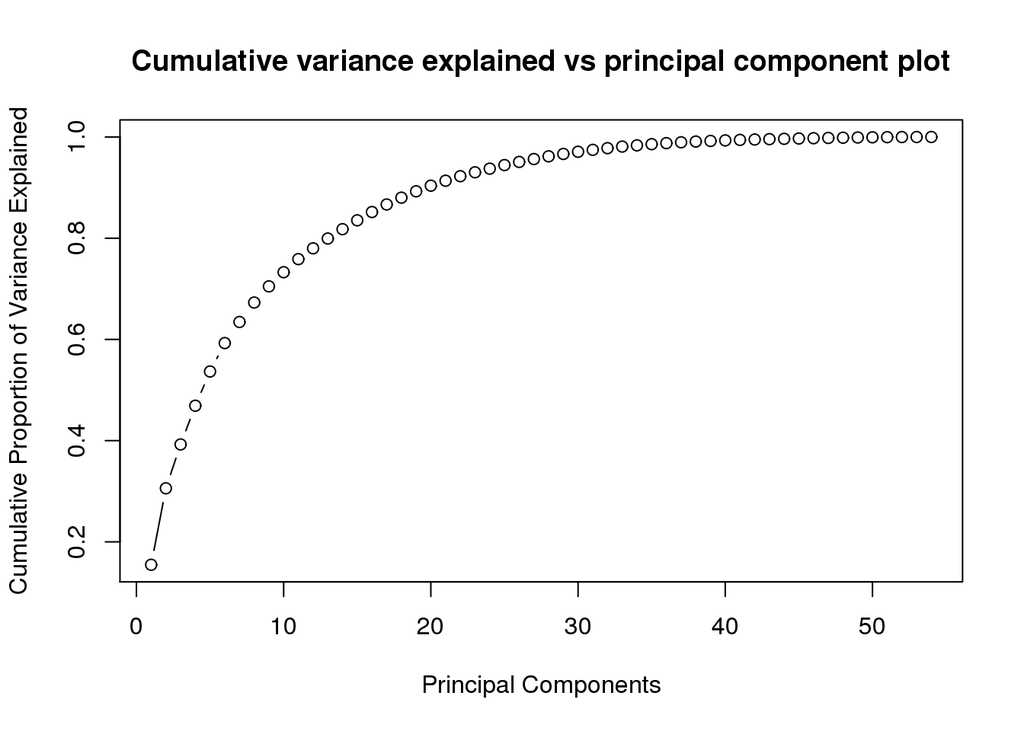

```r
# cleaning test data
test<- test[,-NA_percent_cols$colpos]

# removing 1st 5 columns
training<- training[,-(1:5)]
test<- test[,-(1:5)]
# seperating the target variable
train_target<- training$classe
training<- training[,-55]

training$new_window<- as.numeric(factor(training$new_window))
test$new_window<- as.numeric(factor(test$new_window))

# applying principal component analysis

pr_comp <- prcomp(training, scale = T)

# Getting cumulative relative variance of components
comp_var<- (pr_comp$sdev)^2
cum_comp_var <- cumsum(comp_var/sum(comp_var))


plot(cum_comp_var, xlab = "Principal Components",
              ylab = "Cumulative Proportion of Variance Explained",
              type = "b",
              main="Cumulative variance explained vs principal component plot")
```

```r
# first 38 principal components are selected as predictor in the training and test data
training <-  data.frame(pr_comp$x[,1:38],classe=train_target)

# transforming test data to PCA
test <- predict(pr_comp, newdata = test)
# selecting 1st 38 components
test<- test[,1:38]
```

For cross validation the training set is divided into 2 subsets. One is training subset which contains 75% data of the training set and another is the test subset which contains rest of the 25% data of the training set.

```r
# creating training and test subsets from training data
library(caret)
set.seed(1000)
training_subset_index<-createDataPartition(training$classe, p=0.75, list=FALSE)
training_subset<- training[training_subset_index,]
test_subset<- training[-training_subset_index,]
```

## Training the model for prediction

The following section trains two models using two very popular methods called as support vector machine and Random forest using the training subset data. Thereafter test subset is used to cross validate the model.

```r
library(randomForest)
library(e1071)
set.seed(1000)
# generating support vector machine model from training subset
sv_model<-svm(classe~.,data=training_subset,scale=T)

# generating random forest model from training subset
rf_model <- randomForest(classe ~ ., data=training_subset)

sv_model
```

```
##
## Call:
## svm(formula = classe ~ ., data = training_subset, scale = T)
##
##
## Parameters:
##    SVM-Type:  C-classification
##  SVM-Kernel:  radial
##        cost:  1
##       gamma:  0.02631579
##
## Number of Support Vectors:  6321
```

```r
rf_model
```

```
##
## Call:
##  randomForest(formula = classe ~ ., data = training_subset)
##                Type of random forest: classification
##                      Number of trees: 500
## No. of variables tried at each split: 6
##
##         OOB estimate of  error rate: 1.83%
## Confusion matrix:
##      A    B    C    D    E class.error
## A 4171    6    1    5    2 0.003345281
## B   49 2777   15    4    3 0.024929775
## C    3   29 2515   18    2 0.020257109
## D    3    0   85 2319    5 0.038557214
## E    3    9   15   13 2666 0.014781966
```

```r
# Predicting classes in test subset using svm model
sv_predict_classe <- predict(sv_model, test_subset[,-39])

# Predicting classes in test subset using Random forest model
rf_predict_classe <- predict(rf_model, test_subset[,-39])

# Generating confusion matrix for both the model predictions
confusionMatrix(sv_predict_classe, test_subset$classe)
```

```
## Confusion Matrix and Statistics
##
##           Reference
## Prediction    A    B    C    D    E
##          A 1393   53    5    0    1
##          B    0  879   17    0    2
##          C    0   13  828   58   12
##          D    0    1    3  744   16
##          E    2    3    2    2  870
##
## Overall Statistics
##
##                Accuracy : 0.9613
##                  95% CI : (0.9555, 0.9665)
##     No Information Rate : 0.2845
##     P-Value [Acc > NIR] : < 2.2e-16
##
##                   Kappa : 0.9509
##  Mcnemar's Test P-Value : NA
##
## Statistics by Class:
##
##                      Class: A Class: B Class: C Class: D Class: E
## Sensitivity            0.9986   0.9262   0.9684   0.9254   0.9656
## Specificity            0.9832   0.9952   0.9795   0.9951   0.9978
## Pos Pred Value         0.9594   0.9788   0.9089   0.9738   0.9898
## Neg Pred Value         0.9994   0.9825   0.9932   0.9855   0.9923
## Prevalence             0.2845   0.1935   0.1743   0.1639   0.1837
## Detection Rate         0.2841   0.1792   0.1688   0.1517   0.1774
## Detection Prevalence   0.2961   0.1831   0.1858   0.1558   0.1792
## Balanced Accuracy      0.9909   0.9607   0.9740   0.9602   0.9817
```

```r
confusionMatrix(rf_predict_classe, test_subset$classe)
```

```
## Confusion Matrix and Statistics
##
##           Reference
## Prediction    A    B    C    D    E
##          A 1389   10    1    2    0
##          B    3  936    9    0    0
##          C    0    2  838   27    1
##          D    1    1    7  773    5
##          E    2    0    0    2  895
##
## Overall Statistics
##
##                Accuracy : 0.9851
##                  95% CI : (0.9813, 0.9883)
##     No Information Rate : 0.2845
##     P-Value [Acc > NIR] : < 2.2e-16
##
##                   Kappa : 0.9812
##  Mcnemar's Test P-Value : NA
##
## Statistics by Class:
##
##                      Class: A Class: B Class: C Class: D Class: E
## Sensitivity            0.9957   0.9863   0.9801   0.9614   0.9933
## Specificity            0.9963   0.9970   0.9926   0.9966   0.9990
## Pos Pred Value         0.9907   0.9873   0.9654   0.9822   0.9956
## Neg Pred Value         0.9983   0.9967   0.9958   0.9925   0.9985
## Prevalence             0.2845   0.1935   0.1743   0.1639   0.1837
## Detection Rate         0.2832   0.1909   0.1709   0.1576   0.1825
## Detection Prevalence   0.2859   0.1933   0.1770   0.1605   0.1833
## Balanced Accuracy      0.9960   0.9916   0.9864   0.9790   0.9962
```

The SVM model gave out of sample accuracy on the test subset as 96.13% (out of sample error = 3.87%). Whereas the random forest model gave out of sample accuracy on the test subset as 98.51% (out of sample error = 1.49%) Thus we are choosing the random forest model for predicting the classes in the final test data.

## Final Prediction

The following section predicts the classes in the Final test dataset and writes the output in a csv file

```r
# Predicting classes in final test data
final_predict_classe <- predict(rf_model,test)
final_predict_classe
```

```
##  1  2  3  4  5  6  7  8  9 10 11 12 13 14 15 16 17 18 19 20
##  B  A  B  A  A  E  D  B  A  A  B  C  B  A  E  E  A  B  B  B
## Levels: A B C D E
```

```r
# writing prediction results in csv
write.csv(final_predict_classe,"final_test_prediction.csv")
```